# Chr2_SnpEff

Dave Speca

7/20/2017

#### Preliminaries

Exploratory analysis of SnpEff output indicated that SnpEff ANN= data is appended to the INFO column of the .vcf file (column #8), making it quite unwieldy. But I should be able to use dplyr to search for specific strings (variant calls) that have been added by SnpEff.

#### SnpEff analysis

N.B. I downloaded the latest version of SnpEff into my home directory. Then within the snpEff home directory I ran this command from the Terminal:

`java -Xmx4g -jar snpEff.jar mm10 Chr2/Chr2.all.vcf > Chr2.all.ann.vcf`

This (quite rapidly) generated the Chr2.all.ann.vcf file. N.B. Chr2.all.vcf was 50Mb, Chr2.all.ann.vcf is 71M, so this just adds additional columns of information. Then I started this new R_project (Chr2) after creating a git repository, and I moved the Chr2.all.ann.vcf file to the project’s directory.

```r
library(ggplot2)
library(dplyr)
```

### Read in the vcf file and add headers of Chr2.all.ann.vcf:

```r
# read in .vcf file
Chr2.data <- read.table("Chr2.all.ann.vcf", as.is=TRUE, na.strings=".")
vcf.header <- system("grep '#C' Chr2.all.ann.vcf",intern = TRUE)
vcf.header <- sub("#","",vcf.header) #get rid of the pound sign
vcf.header <- unlist(strsplit(vcf.header,split="\t"))
colnames(Chr2.data) <- vcf.header
head(Chr2.data)
```

```
##   CHROM     POS ID           REF           ALT        QUAL FILTER
## 1  chr2 3050032 NA             A             T 6.73550e-01     NA
## 2  chr2 3050035 NA             A             G 2.49420e-03     NA
## 3  chr2 3050042 NA GAAGGAAGGAAGG AAAAGAAAGAAAC 3.21672e-05     NA
## 4  chr2 3050098 NA             G             A 1.64216e+02     NA
## 5  chr2 3050102 NA         GAAGG   AAAGA,GAAGA 1.73835e+02     NA
## 6  chr2 3050115 NA             T             A 2.88950e+03     NA
##                                                                                                                                                                                                                                                                                                          …
## 1                                                                                                                                                                                                                                                                                              AB=0.35714…
## 2                                                                                                                                                                                                                                                                                   AB=0.285714;ABP=5.802…
## 3                                                                                                                                                                                                                                     AB=0;ABP=0;AC=0;AF=0;AN=4;AO=3;CIGAR=1X2M1X3M1X3M2X;DP=17;DPB=23.46…
## 4                                                                                                                                                                                                                                                                                AB=0.205128;ABP=61.9184;…
## 5 AB=0.157143,0.128571;ABP=74.4828,86.8912;AC=1,1;AF=0.25,0.25;AN=4;AO=11,9;CIGAR=1X3M1X,4M1X;DP=70;DPB=72.6;DPRA=0,0;EPP=3.20771,3.25157;EPPR=5.60547;GTI=0;LEN=5,1;MEANALT=4.5,4.5;MQM=48.3636,53.6667;MQMR=47.3659;NS=2;NUMALT=2;ODDS=11.3445;PAIRED=0.818182,1;PAIREDR=0.756098;PAO=1,1;PQA=36.5,36.5…
## 6                                                                                                                                                                                                                                                                                         AB=0.88;ABP=65.…
##                    FORMAT
```

[output cut: 20 more lines]

The annotations are contained within the “INFO” variable. I will need to extract them.

Also, the chromosomal positions are not ordered. Let’s deal with that now and confirm that the Epac2 mutation is annotated correctly before proceeding.

```r
Chr2.data <- arrange(Chr2.data, POS)
```

### String split data

```r
# Before splitting add NAs to blank cells

Chr2.data$DBA[is.na(Chr2.data$DBA)] <- "NA:NA:NA:NA:NA:NA:NA:NA"

DBA.tmp <- matrix(
  unlist(strsplit(Chr2.data$DBA,split = ":")),
  nrow=nrow(Chr2.data),
  byrow=TRUE
  )
head(DBA.tmp)
```

```
##      [,1]  [,2] [,3]      [,4] [,5]   [,6]   [,7]
## [1,] "0/1" "7"  "4,3"     "4"  "150"  "3"    "90"
## [2,] "0/1" "7"  "5,2"     "5"  "157"  "2"    "63"
## [3,] "0/0" "9"  "5,3"     "5"  "188"  "3"    "65"
## [4,] "0/1" "42" "30,11"   "30" "1069" "11"   "442"
## [5,] "0/1" "40" "22,10,2" "22" "818"  "10,2" "373,82"
## [6,] "1/1" "58" "1,57"    "1"  "41"   "57"   "2238"
##      [,8]
## [1,] "-2.91886,0,-5.8086"
## [2,] "-1.12189,0,-5.78547"
## [3,] "0,-0.309903,-23.0294"
## [4,] "-25.542,0,-63.9405"
## [5,] "-19.2777,0,-47.8382,-19.7838,-44.6755,-70.0595"
## [6,] "-175.515,-13.3652,0"
```

```r
colnames(DBA.tmp) <- paste("DBA",c("gt","tot.depth","NObsAllele", "ref.depth","ref.qual","alt.depth","alt.qual","gen.lik"),sep="_")

Chr2.data$Chr2[is.na(Chr2.data$Chr2)] <- "NA:NA:NA:NA:NA:NA:NA:NA"

Chr2.tmp <- matrix(
  unlist(strsplit(Chr2.data$Chr2,split = ":")),
  nrow=nrow(Chr2.data),
  byrow=TRUE
  )
head(Chr2.tmp)
```

```
##      [,1]  [,2] [,3]     [,4] [,5]   [,6]  [,7]
## [1,] "0/1" "7"  "5,2"    "5"  "167"  "2"   "53"
## [2,] "0/0" "7"  "6,1"    "6"  "233"  "1"   "12"
## [3,] "0/0" "8"  "5,0"    "5"  "183"  "0"   "0"
## [4,] "0/1" "36" "31,5"   "31" "1196" "5"   "165"
## [5,] "0/2" "30" "19,1,7" "19" "691"  "1,7" "40,248"
## [6,] "0/1" "50" "6,44"   "6"  "186"  "44"  "1756"
##      [,8]
## [1,] "-2.5916,0,-12.6"
## [2,] "0,-0.907216,-19.1776"
## [3,] "0,-3.0103,-26.3254"
## [4,] "-4.14112,0,-90.2116"
## [5,] "-11.8588,-15.537,-66.6042,0,-48.64,-49.2292"
## [6,] "-130.929,0,-1.98871"
```

```r
colnames(Chr2.tmp) <- paste("Chr2",c("gt","tot.depth","NObsAllele", "ref.depth","ref.qual","alt.depth","alt.qual","gen.lik"),sep="_")

Chr2.data <- cbind(Chr2.data,DBA.tmp,Chr2.tmp,stringsAsFactors=FALSE)
summary(Chr2.data)
```

```
##     CHROM                POS               ID              REF
##  Length:116978      Min.   :  3050032   Mode:logical   Length:116978
##  Class :character   1st Qu.: 65796193   NA's:116978    Class :character
##  Mode  :character   Median :119039558                  Mode  :character
##                     Mean   :105149628
##                     3rd Qu.:144054115
##                     Max.   :182012772
##      ALT                 QUAL            FILTER            INFO
##  Length:116978      Min.   :      0.0   Mode:logical   Length:116978
##  Class :character   1st Qu.:     25.7   NA's:116978    Class :character
##  Mode  :character   Median :     62.5                  Mode  :character
##                     Mean   :    595.2
##                     3rd Qu.:    136.2
##                     Max.   :2355690.0
##     FORMAT              DBA                Chr2
##  Length:116978      Length:116978      Length:116978
##  Class :character   Class :character   Class :character
##  Mode  :character   Mode  :character   Mode  :character
##
##
##
##     DBA_gt          DBA_tot.depth      DBA_NObsAllele
##  Length:116978      Length:116978      Length:116978
##  Class :character   Class :character   Class :character
##  Mode  :character   Mode  :character   Mode  :character
##
##
##
##  DBA_ref.depth      DBA_ref.qual       DBA_alt.depth
##  Length:116978      Length:116978      Length:116978
##  Class :character   Class :character   Class :character
##  Mode  :character   Mode  :character   Mode  :character
##
##
##
##  DBA_alt.qual       DBA_gen.lik          Chr2_gt
##  Length:116978      Length:116978      Length:116978
##  Class :character   Class :character   Class :character
##  Mode  :character   Mode  :character   Mode  :character
##
```

[output cut: 8 more lines]

```
##
##  Chr2_ref.qual      Chr2_alt.depth     Chr2_alt.qual
##  Length:116978      Length:116978      Length:116978
##  Class :character   Class :character   Class :character
##  Mode  :character   Mode  :character   Mode  :character
##
##
##
##  Chr2_gen.lik
##  Length:116978
##  Class :character
##  Mode  :character
##
##
##
```

### Convert columns back to numeric:

```r
Chr2.data[,c("DBA_tot.depth","DBA_ref.depth","DBA_ref.qual","DBA_alt.depth","DBA_alt.qual",
            "Chr2_tot.depth","Chr2_ref.depth","Chr2_ref.qual","Chr2_alt.depth","Chr2_alt.qual")] <-
  apply(Chr2.data[,c("DBA_tot.depth","DBA_ref.depth","DBA_ref.qual","DBA_alt.depth","DBA_alt.qual",
            "Chr2_tot.depth","Chr2_ref.depth","Chr2_ref.qual","Chr2_alt.depth","Chr2_alt.qual")],
        2,
        as.numeric
        )
head(Chr2.data, 6)
```

```
##   CHROM     POS ID           REF           ALT        QUAL FILTER
## 1  chr2 3050032 NA             A             T 6.73550e-01     NA
## 2  chr2 3050035 NA             A             G 2.49420e-03     NA
## 3  chr2 3050042 NA GAAGGAAGGAAGG AAAAGAAAGAAAC 3.21672e-05     NA
## 4  chr2 3050098 NA             G             A 1.64216e+02     NA
## 5  chr2 3050102 NA         GAAGG   AAAGA,GAAGA 1.73835e+02     NA
## 6  chr2 3050115 NA             T             A 2.88950e+03     NA
##                                                                                                                                                                                                                                                                                                          …
## 1                                                                                                                                                                                                                                                                                              AB=0.35714…
## 2                                                                                                                                                                                                                                                                                   AB=0.285714;ABP=5.802…
## 3                                                                                                                                                                                                                                     AB=0;ABP=0;AC=0;AF=0;AN=4;AO=3;CIGAR=1X2M1X3M1X3M2X;DP=17;DPB=23.46…
## 4                                                                                                                                                                                                                                                                                AB=0.205128;ABP=61.9184;…
## 5 AB=0.157143,0.128571;ABP=74.4828,86.8912;AC=1,1;AF=0.25,0.25;AN=4;AO=11,9;CIGAR=1X3M1X,4M1X;DP=70;DPB=72.6;DPRA=0,0;EPP=3.20771,3.25157;EPPR=5.60547;GTI=0;LEN=5,1;MEANALT=4.5,4.5;MQM=48.3636,53.6667;MQMR=47.3659;NS=2;NUMALT=2;ODDS=11.3445;PAIRED=0.818182,1;PAIREDR=0.756098;PAO=1,1;PQA=36.5,36.5…
## 6                                                                                                                                                                                                                                                                                         AB=0.88;ABP=65.…
##                    FORMAT
```

[output cut: 55 more lines]

### Subset Chr2.data QUAL > 40

```r
# subset data keeping only SNPs with quality scores greater than or equal to 40
Chr2.Q40.data <- subset(Chr2.data, QUAL >= 40)
```

### Make it a little more user-friendly

```r
Chr2.Q40.tidy.data <-select(Chr2.Q40.data, -ID, -FILTER, -FORMAT, -DBA, -Chr2, -DBA_gen.lik, -Chr2_gen.lik, -DBA_NObsAllele, -Chr2_NObsAllele)
```

### Plot Chr2 congenic-specific SNPs (Chr2_gt==1/1) to define introgressed region

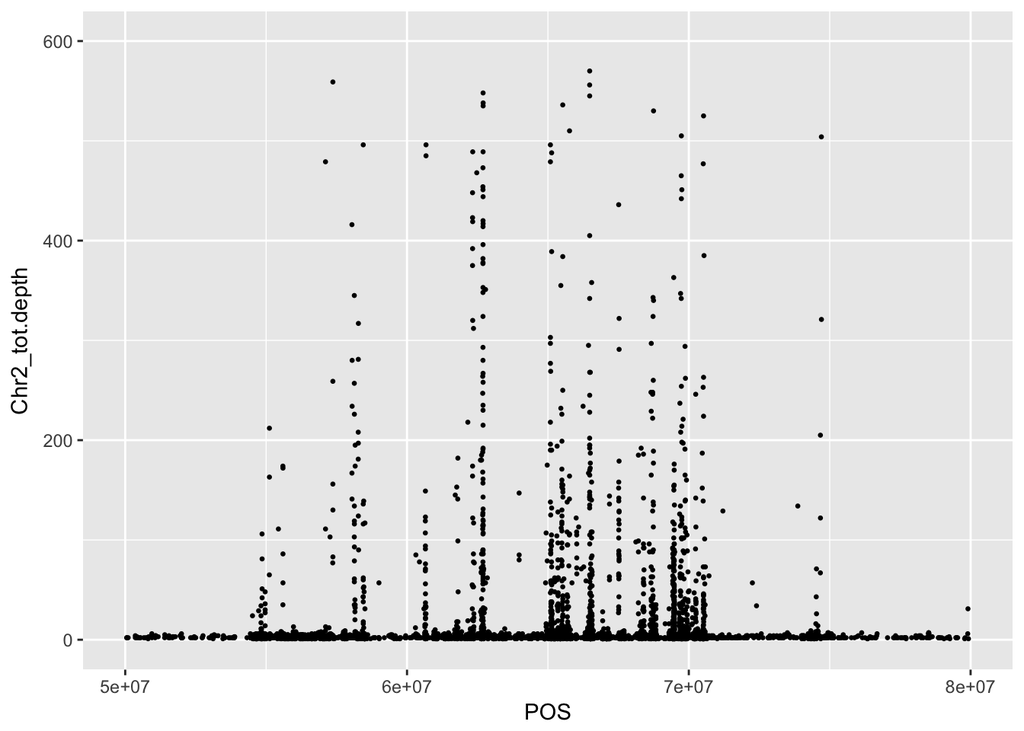

```r
library(ggplot2)
###subset Chr2_gt=="1/1"
Chr2.XX11.data <- subset(Chr2.Q40.tidy.data, Chr2_gt=="1/1")
###plot these SNPs using total depth on y-axis and position on x-axis
plot.snps <- ggplot(Chr2.XX11.data , aes(x=POS, y=Chr2_tot.depth)) + geom_point(size = 0.5) + ylim(0,600) + xlim(5.0e+7, 8.0e+7)
plot.snps
```

### This looks reasonable. It looks like the introgressed region is safely in between ~52.0 Mb and 75.0 Mb.

### Subset SNPs between 52.0 and 75.0 Mb

```r
Chr2.Q40.congenic.tidy.data <- filter(Chr2.Q40.tidy.data, POS > 52000000 & POS < 75000000)
```

```r
# stop_gained
stop_gained <- filter(Chr2.Q40.congenic.tidy.data, grepl("stop_gained", INFO))
```

### Let’s make a table!

```r
# count the numbers common and unique to each genotype
ftable(Chr2.Q40.congenic.tidy.data[,c("DBA_gt","Chr2_gt")])
```

```
##        Chr2_gt  0/0  0/1  0/2  0/3  1/1  1/2  1/3  2/2  3/3   NA
## DBA_gt
## 0/0               0   41    0    0   80    2    0    0    0    0
## 0/1             166  130    1    0  172    6    0    2    0   81
## 0/2               0    1    0    0    1    0    0    0    0    0
## 1/1            1051  177    2    0 2797   21    0    8    0 2583
## 1/2              11    4    0    1   25   19    1    0    2   26
## 1/3               0    0    0    0    0    2    0    2    0    0
## 2/2               0    3    0    0   14    0    4    0    0    0
## 3/3               0    0    0    0    0    1    0    0    0    0
## NA                0   44    0    0 1963   17    0    0    0    0
```

```r
# eliminate SNPs that are DBA_gt==1/1 & Chr2_gt==1/1
Chr2.FNL.data <- subset(Chr2.Q40.congenic.tidy.data,!(DBA_gt=="1/1" & Chr2_gt == "1/1"))
Chr2.FNL.data <- subset(Chr2.FNL.data, !(DBA_gt=="0/1" & Chr2_gt=="0/1"))
Chr2.FNL.data <- subset(Chr2.FNL.data, !(DBA_gt=="1/2" & Chr2_gt=="1/2"))
```

### Let’s start looking for meaningful variants!

```r
# stop_lost
stop_lost <- filter(Chr2.FNL.data, grepl("stop_lost", INFO))
# start_lost
start_lost <- filter(Chr2.FNL.data, grepl("start_lost", INFO))
# splice_region_variant
splice_region_variant <- filter(Chr2.FNL.data, grepl("splice_region_variant", INFO))
# !intergenic_region & intron_variant
Chr2.InGene <- filter(Chr2.FNL.data, !grepl("intergenic_region|intron_variant", INFO))
```

```r
# INFO score == "HIGH"
HIGH <- filter(Chr2.InGene, grepl("HIGH", INFO))
# only detects Epac2 mutation.

# INFO score == "MODERATE"
MODERATE <- filter(Chr2.InGene, grepl("MODERATE", INFO))
```

### Did not find any meaningful variants in genes other than Epac2